# 2023年度労務管理論

2023-05-15 19:23:51

## 労働力

## 労働力とは？

- 働くことができそうな人々
- 人的資源Human resourceとほぼ同義
  - 人的資源は推定しないとわからない
  - 労働力も統計的に推定されるが、統計上の区分異なる
  - 歴史的には「人材」「従業員」と同一視されてきた

## 労働力調査

1. 総務省統計局による月次調査
2. 労働者対象
3. 国際比較可能
4. 最大規模かつ継続的
5. 標本調査

## 1. 総務省統計局による月次調査

- 政府による基幹統計の一
- 53つある基幹統計一覧は以下参照

[figure not shown]

## 2. 労働者対象

- 訪問調査
  - 事業所対象ではない
  - 毎年6月頃から開始
- 労働者ではない人々も対象
  - 層化二段階抽出にて都道府県から住戸へ絞り込む
  - 住戸に住むすべての世帯が対象

## 3. 国際比較可能

- ILOによる方式準拠
  - 完全にしたがう必要はない 例）完全失業率
  - 国ごとに異なる項目を追加してもかまわない

## 4. 最大規模かつ継続的

- 1953年から継続中
  - 1972年と1984年に改定あり。接続困難だが補正式が提案さる。
  - データはeStatからダウンロード可能。MSExcelフォーマットが無難。APIはあまりおすすめしない。
- 投入される人員と予算も大きい
  - 各都道府県にて動員される調査員は総数不明だが膨大
  - 1,509,704,000円。国勢調査を除いて最大

## 5. 標本調査

- 算出された値は統計上の誤差を含む推定値
- 集計後になんやら非標本誤差が蓄積するようなことが行われているかもしれない
- 参考 悉皆調査（センサス）
  - すべて調べる 例）国勢調査
  - 莫大な手間がかかる 例）国勢調査は5年に1度

## 労働力調査以外の方法

- 国勢調査
- 就業構造基本調査
- 毎月勤労統計調査
- 経済センサス

## 統計上の区分（2018年-）

- 15歳以上人口
  - 労働力人口
    - 就業者—**追加就労希望者**
    - **失業者**—完全失業者
  - 非労働力人口
    - **潜在労働力人口**—**拡張求職者・就業可能非求職者**

## 新区分

### ILOとは多少異なる

- 追加就労希望者：週35時間未満就業中、就業追加希望、就業追加可能
- 失業者：就業してない、**1ヶ月以内**に求職（完全失業者は1週間以内）、すぐ就業可
- 潜在労働力人口：
  - 拡張求職者：修行してない、**1ヶ月以内**に求職、**2週間以内**に就業可
  - 就業可能非求職者：**1ヶ月以内**に求職、**就業希望**、すぐ就業可

## 現有勢力（2023年3月、季節調整済、単位：万人）

- 15歳以上人口（現数値）：10,993（うち男5,301女5,692）
- 労働力人口：6,872（うち男3,775女3,097）
- 就業者：6,676（うち男3,663女3,013）
- 完全失業者：176（うち男107,女68）
- 非労働力人口：4,121（うち男1,526女2,595）

## LACSにアップロードしたグラフをながめながらまいります

- 毎度おなじみRでつくりました。美麗ですね。
- 主要指標のみ抽出します。
- 欠損は、官庁が抱える問題意識変容を示す。
  - 2011年は東日本大震災

## 労働力人口

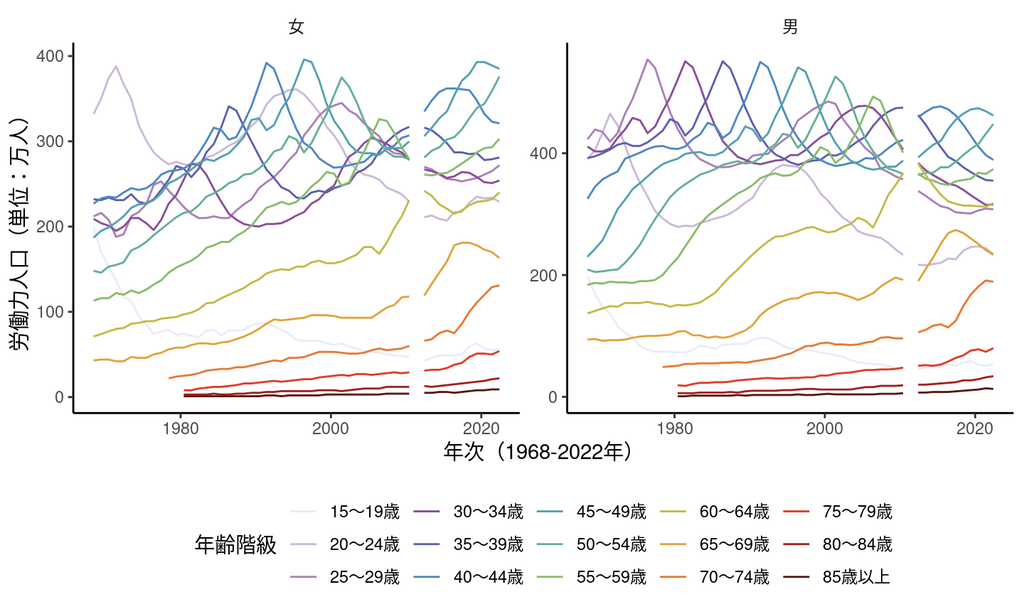

## 就業者数

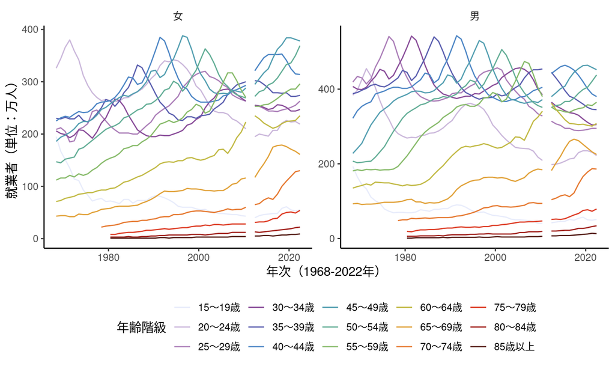

## 完全失業者数

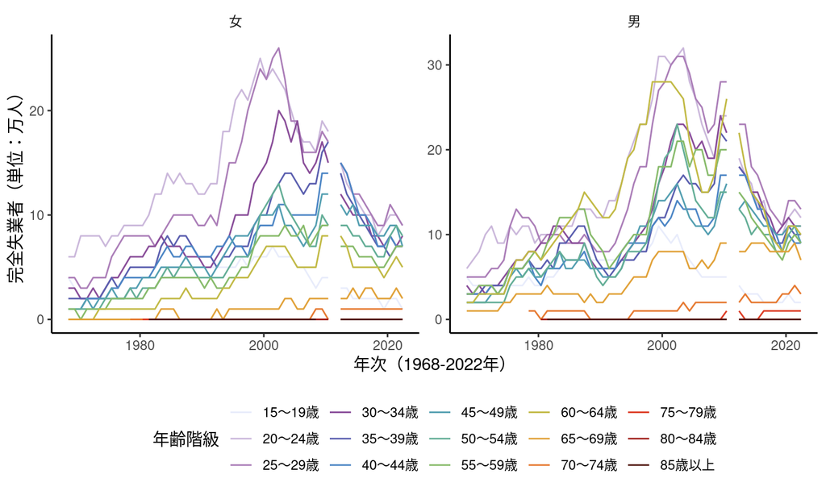

## 非労働力人口

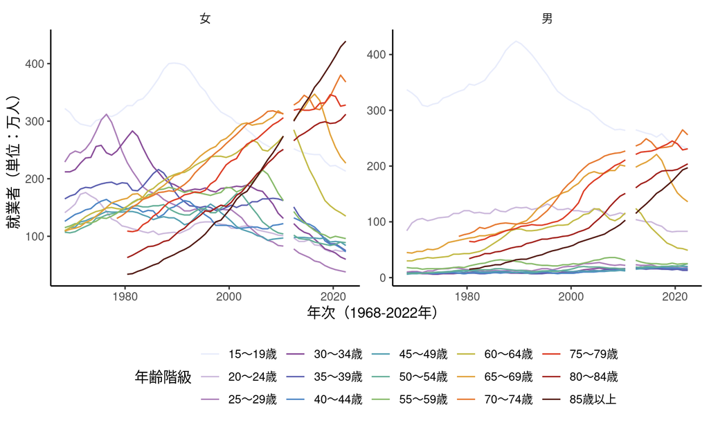

## 就業者に雇用者が占める割合

### 少しは経営らしい話もしましょうか

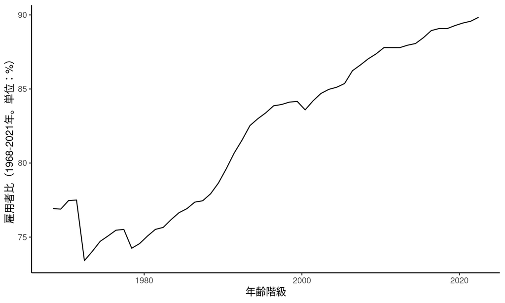

## 論点

1. M字カーブ
2. 完全失業率上昇傾向
3. 雇用形態別勢力推移
4. 終身雇用

## そのまえに

- 労働力率(LPR)：働けそうな人々の割合。現在わが国は62%前後（男71女54） \[ LPR = \frac{労働力人口}{15歳以上人口} \]
- 英語でLabour participation rateというので、労働参加率と直訳することがある（あまりよくない）

## 1. M字カーブ

- 女性における年齢階級別労働力率がM字を描いていた減少
  - 結婚・出産にて退職、非労働力人口へ移行。爾後、さまざまな理由から就業して労働力人口へと移行
  - 女性が意図して示す行動かもしれない
  - 「よいこと」かどうかは別
- 近年は「谷」が右上方へシフト
  - 人口学的説明：学歴上昇と晩婚
  - 経済学的説明：所得減少
- 男性は台形。合計も台形

## M字カーブ

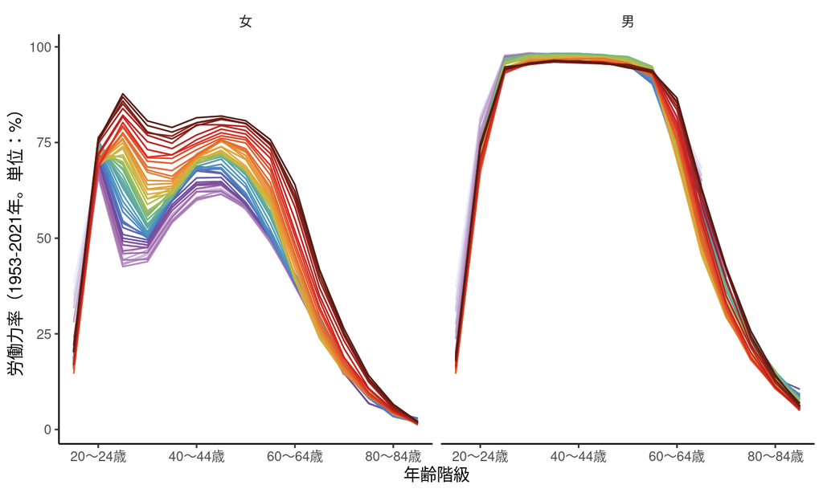

## M字カーブ解説

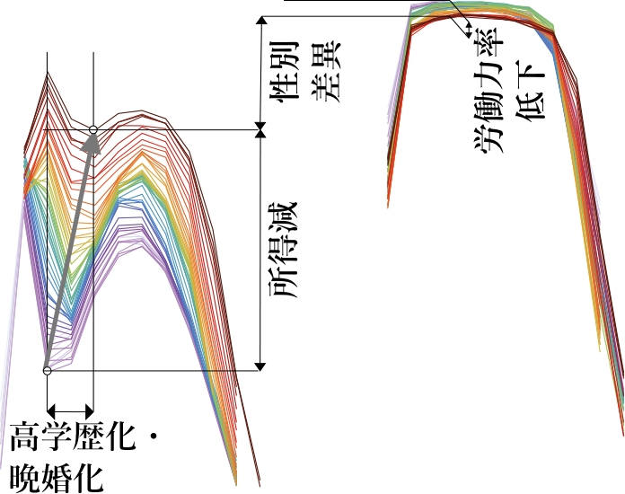

## 2. 完全失業率変動

- 完全失業率：労働力人口のうち完全失業者が占める割合。遅行系列の一種
- 傾向的には上昇。短期的には下降
  - バブル経済崩壊後に急上昇
  - 直近10年は下降

## 2010年以降、急落した理由

- 全年齢階級において完全失業者数減少
  - いわゆる人手不足に関する根拠
  - 人手不足=使用者が希望しても雇用できないこと
- 就業者数（特に45歳以上）増加
  - 高齢になっても働かなければならないことの裏返し
  - 労働者にとってよい結果であるかわからない

## 人手不足か?

- そうとばかりも言い切れない
  - 労働力人口は増加。就業者も雇用者も増加=労働者を採用することができた
  - 完全失業率は短期的に下降しているが長期には上昇傾向=潜在的に活用可能な労働力が増大する可能性
- いわゆるミスマッチが過剰に強調されているだけかも
  - 「近頃の若いものはまったく!!」
  - 企業が労働者が望む職務や待遇（労働時間、賃金など）を提供できないせいかもしれない

## 参考文献

- 『厚生労働白書』：言わずとしれた情報源。
- 『労働力調査』のホームページ
  - データだけではなく、標本設計に関する解説も一読されたい。価値がある。
  - かんたんガイドも大変親切。

## クイズ

### 2023年5月16日12時15分締切。要長大Googleアカウント。

[figure not shown]